# U-Pb dating method

Dr. Ahmad Redaa

2024-10-15

# What is U-Pb Dating?

- **U-Pb dating** is a radiometric method that measures the decay of uranium isotopes (U-238 and U-235) into lead isotopes (Pb-206 and Pb-207).
- **Applications**: Dates minerals like zircon, apatite, monazite, and titanite … and more

# Geochemistry of Uranium

- **Uranium Isotopes**:
  - U-238 → Pb-206 (Half-life: ~4.47 billion years).
  - U-235 → Pb-207 (Half-life: ~704 million years).
- **Key Minerals**: Zircon (ZrSiO₄), baddeleyite, titanite, monazite.
- **Behavior in Nature**:
  - **Solubility**: Uranium is soluble in oxidizing conditions, especially in the form of U(VI) (uranyl ion $\text{UO}_2^{2+}$).
  - **Oxidation States**:
    - **U(VI)**: Uranium in the +6 oxidation state, highly mobile in aqueous solutions.
    - **U(IV)**: Uranium in the +4 oxidation state, less soluble and immobile in reducing environments.
  - **Compatibility**:
    - Uranium is an **incompatible element** in mafic minerals (like olivine and pyroxene) because it does not easily fit into their crystal structures.
    - **Uranium prefers felsic magmas** rich in silica, where it concentrates in accessory minerals like zircon, monazite, and titanite during the later stages of crystallization.
  - **Crystallization Stages**:
    - Uranium is usually incorporated in the later stages of crystallization from silica-rich magmas.
    - In mafic rocks, which crystallize earlier from magma and have lower silica content, uranium is not compatible and thus is not typically found in significant concentrations.
  - **Link to Rock Types**:
    - **Mafic rocks** (rich in magnesium and iron) crystallize early from magma, excluding uranium.
    - **Felsic rocks** (rich in silica) crystallize later, allowing uranium to become concentrated in accessory minerals like zircon.
  - **Movement and Leaching**: Uranium is mobile in oxidizing environments but becomes immobile in reducing conditions, where U(IV) precipitates.
  - **Fractionation**: Uranium can be fractionated during weathering and hydrothermal processes, leaching out in oxidizing conditions and redepositing in reducing environments.
  - **Importance**: Understanding uranium’s movement and compatibility is important in determining which minerals retain U-Pb isotopic systems for accurate dating.

# U-Pb Dating Equations (General Decay)

- General Decay Equation:
  $$D = D_0 + P \left( e^{\lambda t} - 1 \right)$$
  - **D** = present amount of daughter isotope (Pb)
  - **D₀** = initial amount of daughter isotope (Pb)
  - **P** = present amount of parent isotope (U)
  - **λ** = decay constant of parent isotope
  - **t** = age
- **U-238 to Pb-206**:
  $$\frac{^{206}\text{Pb}}{^{204}\text{Pb}} =
  \frac{^{206}\text{Pb}_0}{^{204}\text{Pb}} +
  \frac{^{238}\text{U}}{^{204}\text{Pb}} \left( e^{\lambda_{238} t} - 1
  \right)$$
- **U-235 to Pb-207**:
  $$\frac{^{207}\text{Pb}}{^{204}\text{Pb}} =
  \frac{^{207}\text{Pb}_0}{^{204}\text{Pb}} +
  \frac{^{235}\text{U}}{^{204}\text{Pb}} \left( e^{\lambda_{235} t} - 1
  \right)$$

# Challenges of U-Pb Dating

- **Open System**: Geological processes (metamorphism, recrystallization) can “open” the system.
- **Effect**: Lead or uranium may escape or enter, causing inaccurate age calculations.
- **Pb²⁰⁴** is a non-radiogenic isotope with very low natural abundance; therefore, accurate measurement of the measurement is challenging.
- Pb²⁰⁴ has **isobaric interference** with Hg²⁰⁴, which complicate its detection during in-situ analyses (e.g., LA-ICP-MS).

# Age Equation for Pb²⁰⁶ (from U²³⁸ decay):

Assuming there is no common lead (i.e., no initial Pb²⁰⁶ is present at the time of sample formation), the relationship between Pb²⁰⁶ and U²³⁸ is given by the equation:

$$^{206}\text{Pb} = ^{238}\text{U} (e^{\lambda_{238} t} - 1)$$

Where:  
- $^{206}\text{Pb}$ is the amount of radiogenic lead-206 produced.  
- $^{238}\text{U}$ is the present amount of uranium-238.  
- $\lambda_{238}$ is the decay constant of U²³⁸.  
- $t$ is the age of the sample.

Rearranging this equation to solve for $t$, we get:

$$t = \frac{1}{\lambda_{238}} \ln \left(
\frac{^{206}\text{Pb}}{^{238}\text{U}} + 1 \right)$$

# Age Equation for Pb²⁰⁷ (from U²³⁵ decay):

Similarly, for Pb²⁰⁷ and U²³⁵, the equation is:

$$^{207}\text{Pb} = ^{235}\text{U} (e^{\lambda_{235} t} - 1)$$

Where:  
- $^{207}\text{Pb}$ is the amount of radiogenic lead-207 produced.  
- $^{235}\text{U}$ is the present amount of uranium-235.  
- $\lambda_{235}$ is the decay constant of U²³⁵.  
- $t$ is the age of the sample.

Rearranging this equation to solve for $t$:

$$t = \frac{1}{\lambda_{235}} \ln \left(
\frac{^{207}\text{Pb}}{^{235}\text{U}} + 1 \right)$$

# Combining U-238 and U-235 Systems

- **Concordia Diagram**: Combines U-238 and U-235 systems to identify accurate ages even in disturbed systems.
- **Wetherill Concordia Diagram**:
  - Plots $\frac{^{207}\text{Pb}}{^{235}\text{U}}$ vs. $\frac{^{206}\text{Pb}}{^{238}\text{U}}$.

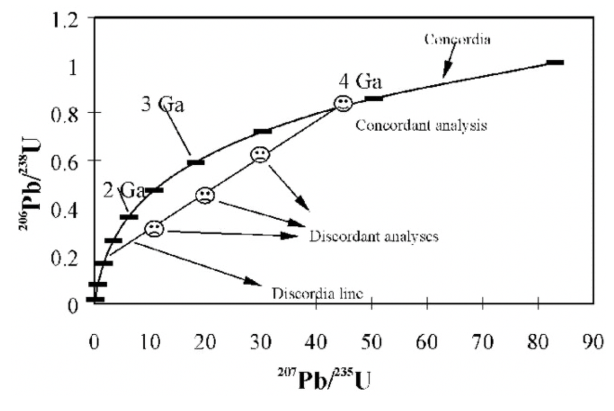

Source: (Machado and Simonetti, 2001)

# Tera–Wasserburg Concordia Diagram

- **Tera–Wasserburg Concordia Diagram**:
  - Plots $\frac{^{238}\text{U}}{^{206}\text{Pb}}$ vs. $\frac{^{207}\text{Pb}}{^{206}\text{Pb}}$.

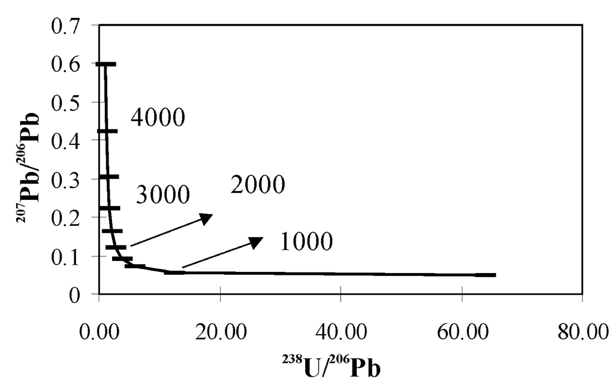

Source: (Machado and Simonetti, 2001)

# Discordia Diagram

- **Discordia Line**: Formed when geological processes disturb the U-Pb system.
- **Interpretation**:
  - Upper intercept = crystallization age.
  - Lower intercept = disturbance (e.g., metamorphism).

# Summary

- **U-Pb dating**: Reliable method combining U-238 and U-235 systems.
- **Concordia diagrams**: Useful for accurate dating and detecting disturbances.
- **Discordia diagrams**: Reveal both crystallization and disturbance events in a rock’s history.